# Lab 6

Author

Caitlin Rasbid

Published

April 4, 2025

```r
library(tidyverse)
library(tidymodels)
library(powerjoin)
library(glue)
library(vip)
library(baguette)
```

```r
root  <- 'https://gdex.ucar.edu/dataset/camels/file'
download.file('https://gdex.ucar.edu/dataset/camels/file/camels_attributes_v2.0.pdf',
              'data/camels_attributes_v2.0.pdf')
```

```r
types <- c("clim", "geol", "soil", "topo", "vege", "hydro")

remote_files  <- glue('{root}/camels_{types}.txt')

local_files   <- glue('data/camels_{types}.txt')

walk2(remote_files, local_files, download.file, quiet = TRUE)

camels <- map(local_files, read_delim, show_col_types = FALSE)

camels <- power_full_join(camels ,by = 'gauge_id')
```

# Question 1

The zero_q_freq variable is the frequency of days where Q = 0 mm/day as a percentage, with Q being discharge, a measure of the volume of water flowing past a point on a stream.

# Exploratory Data Analysis

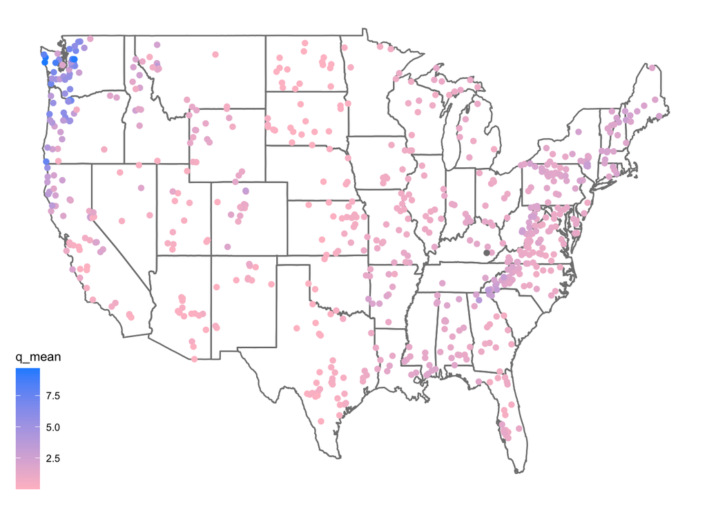

```r
ggplot(data = camels, aes(x = gauge_lon, y = gauge_lat)) +
  borders("state", colour = "gray50") +
  geom_point(aes(color = q_mean)) +
  scale_color_gradient(low = "pink", high = "dodgerblue") +
  ggthemes::theme_map()
```

# Question 2

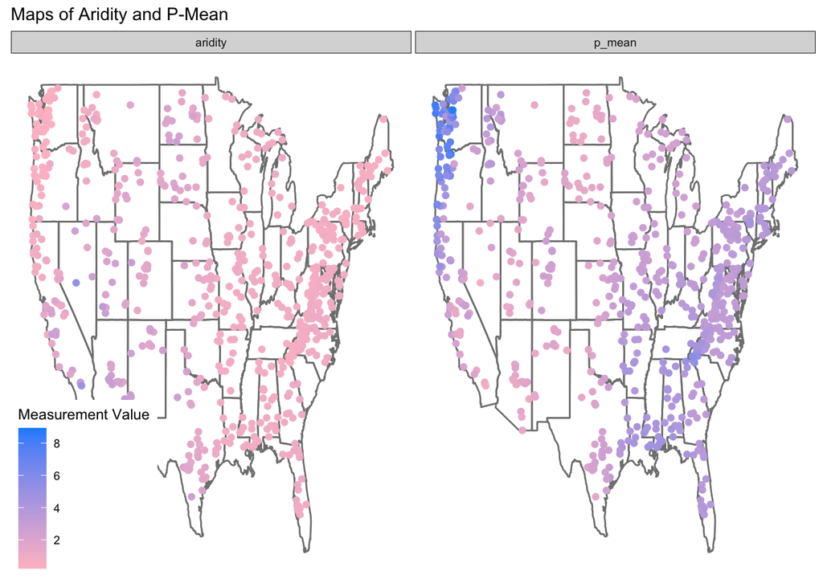

```r
camels_long <- camels %>%
  pivot_longer(cols = c(aridity, p_mean),
               names_to = "variable",
               values_to = "value")

ggplot(data = camels_long, aes(x = gauge_lon, y = gauge_lat)) +
  borders("state", colour = "gray50") +
  geom_point(aes(color = value)) +
  scale_color_gradient(low = "pink", high = "dodgerblue") +
  ggthemes::theme_map() +
  facet_wrap(~ variable, scales = "free") +
  scale_color_gradient(low = "pink", high = "dodgerblue") +
  labs(
    title = "Maps of Aridity and P-Mean",
    x = "Longitude",
    y = "Latitude",
    color = "Measurement Value"
  )
```

# Model Preparation & Building

```r
camels |>
  select(aridity, p_mean, q_mean) |>
  drop_na() |>
  cor()
```

```
           aridity     p_mean     q_mean
aridity  1.0000000 -0.7550090 -0.5817771
p_mean  -0.7550090  1.0000000  0.8865757
q_mean  -0.5817771  0.8865757  1.0000000
```

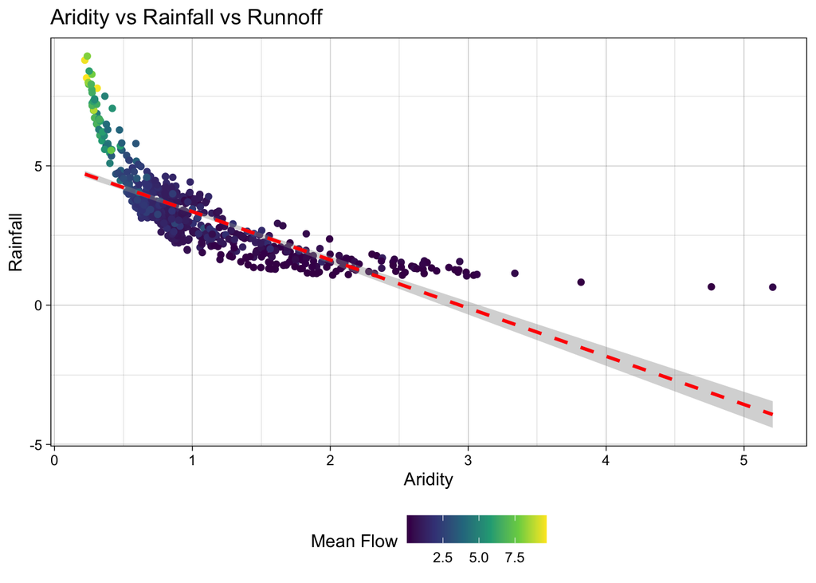

```r
ggplot(camels, aes(x = aridity, y = p_mean)) +
  geom_point(aes(color = q_mean)) +
  geom_smooth(method = "lm", color = "red", linetype = 2) +
  scale_color_viridis_c() +
  theme_linedraw() +
  theme(legend.position = "bottom") +
  labs(title = "Aridity vs Rainfall vs Runnoff",
       x = "Aridity",
       y = "Rainfall",
       color = "Mean Flow")
```

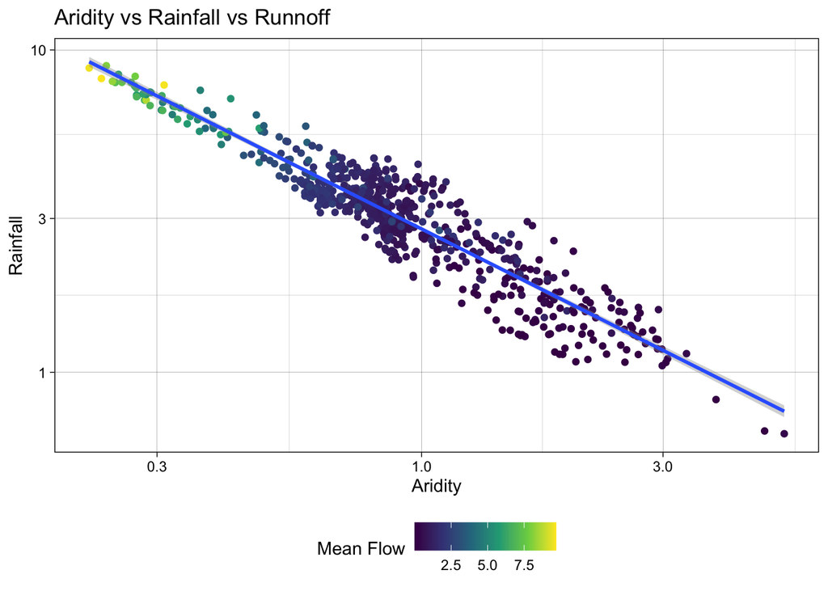

```r
ggplot(camels, aes(x = aridity, y = p_mean)) +
  geom_point(aes(color = q_mean)) +
  geom_smooth(method = "lm") +
  scale_color_viridis_c() +
  scale_x_log10() +
  scale_y_log10() +
  theme_linedraw() +
  theme(legend.position = "bottom") +
  labs(title = "Aridity vs Rainfall vs Runnoff",
       x = "Aridity",
       y = "Rainfall",
       color = "Mean Flow")
```

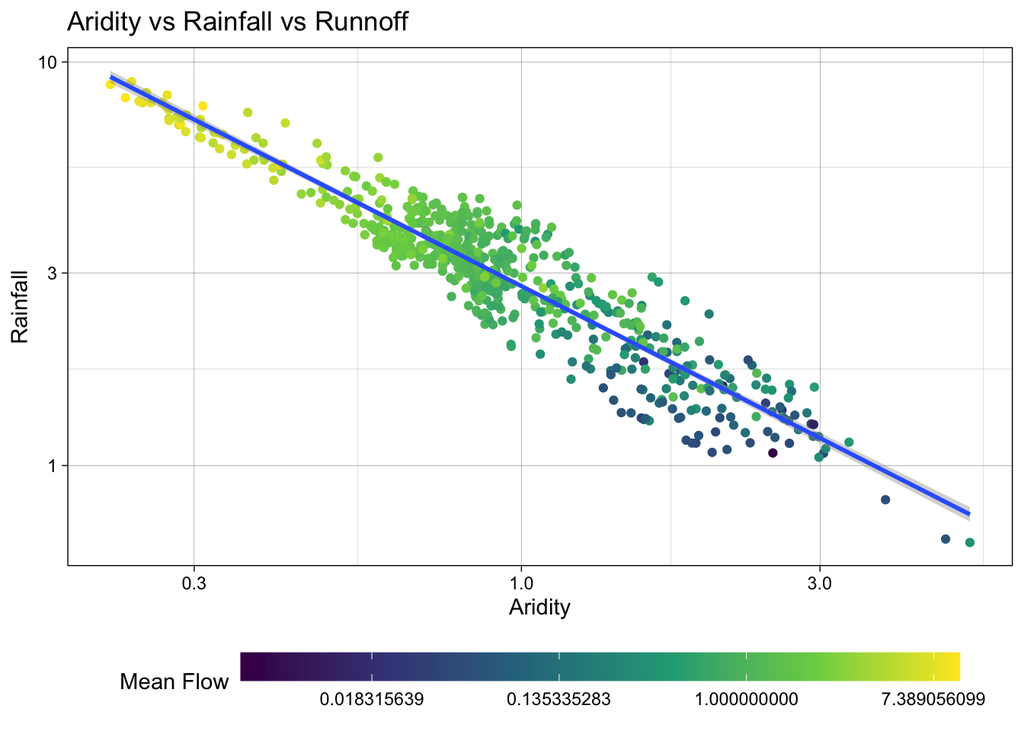

```r
ggplot(camels, aes(x = aridity, y = p_mean)) +
  geom_point(aes(color = q_mean)) +
  geom_smooth(method = "lm") +
  scale_color_viridis_c(trans = "log") +
  scale_x_log10() +
  scale_y_log10() +
  theme_linedraw() +
  theme(legend.position = "bottom",
        legend.key.width = unit(2.5, "cm"),
        legend.key.height = unit(.5, "cm")) +
  labs(title = "Aridity vs Rainfall vs Runnoff",
       x = "Aridity",
       y = "Rainfall",
       color = "Mean Flow")
```

```r
set.seed(123)

camels <- camels |>
  mutate(logQmean = log(q_mean))

camels_split <- initial_split(camels, prop = 0.8)
camels_train <- training(camels_split)
camels_test  <- testing(camels_split)

camels_cv <- vfold_cv(camels_train, v = 10)
```

```r
rec <-  recipe(logQmean ~ aridity + p_mean, data = camels_train) %>%
  step_log(all_predictors()) %>%
  step_interact(terms = ~ aridity:p_mean) |>
  step_naomit(all_predictors(), all_outcomes())
```

```r
baked_data <- prep(rec, camels_train) |>
  bake(new_data = NULL)

lm_base <- lm(logQmean ~ aridity * p_mean, data = baked_data)
summary(lm_base)
```

```
Call:
lm(formula = logQmean ~ aridity * p_mean, data = baked_data)

Residuals:
     Min       1Q   Median       3Q      Max
-2.91162 -0.21601 -0.00716  0.21230  2.85706

Coefficients:
               Estimate Std. Error t value Pr(>|t|)
(Intercept)    -1.77586    0.16365 -10.852  < 2e-16 ***
aridity        -0.88397    0.16145  -5.475 6.75e-08 ***
p_mean          1.48438    0.15511   9.570  < 2e-16 ***
aridity:p_mean  0.10484    0.07198   1.457    0.146
---
Signif. codes:  0 '***' 0.001 '**' 0.01 '*' 0.05 '.' 0.1 ' ' 1

Residual standard error: 0.5696 on 531 degrees of freedom
Multiple R-squared:  0.7697,    Adjusted R-squared:  0.7684
F-statistic: 591.6 on 3 and 531 DF,  p-value: < 2.2e-16
```

```r
summary(lm(logQmean ~ aridity + p_mean + aridity_x_p_mean, data = baked_data))
```

```
Call:
lm(formula = logQmean ~ aridity + p_mean + aridity_x_p_mean,
    data = baked_data)

Residuals:
     Min       1Q   Median       3Q      Max
-2.91162 -0.21601 -0.00716  0.21230  2.85706

Coefficients:
                 Estimate Std. Error t value Pr(>|t|)
(Intercept)      -1.77586    0.16365 -10.852  < 2e-16 ***
aridity          -0.88397    0.16145  -5.475 6.75e-08 ***
p_mean            1.48438    0.15511   9.570  < 2e-16 ***
aridity_x_p_mean  0.10484    0.07198   1.457    0.146
---
Signif. codes:  0 '***' 0.001 '**' 0.01 '*' 0.05 '.' 0.1 ' ' 1

Residual standard error: 0.5696 on 531 degrees of freedom
Multiple R-squared:  0.7697,    Adjusted R-squared:  0.7684
F-statistic: 591.6 on 3 and 531 DF,  p-value: < 2.2e-16
```

```r
test_data <-  bake(prep(rec), new_data = camels_test)
test_data$lm_pred <- predict(lm_base, newdata = test_data)

metrics(test_data, truth = logQmean, estimate = lm_pred)
```

```
# A tibble: 3 × 3
  .metric .estimator .estimate
  <chr>   <chr>          <dbl>
1 rmse    standard       0.583
2 rsq     standard       0.742
3 mae     standard       0.390
```

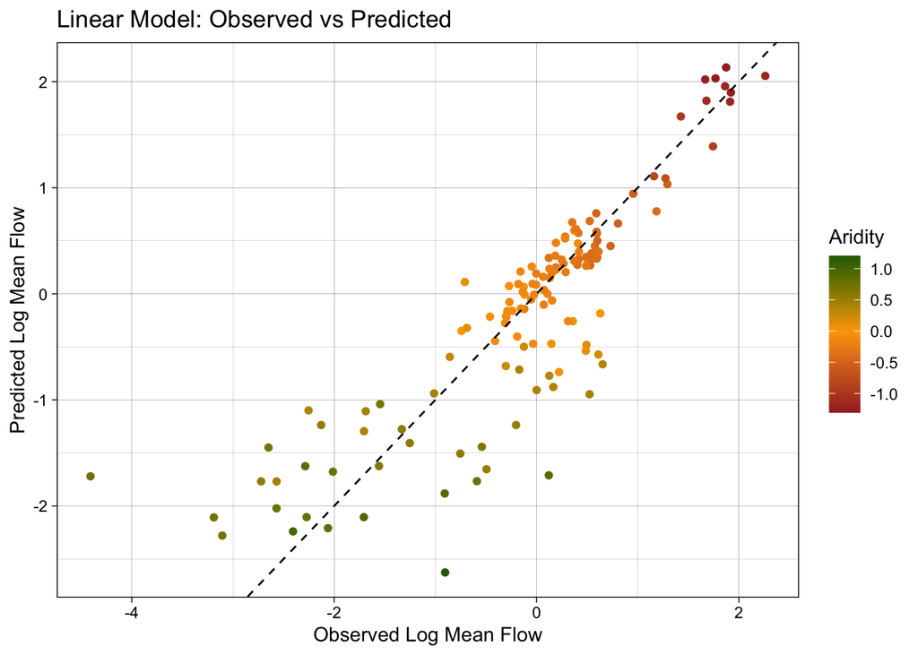

```r
ggplot(test_data, aes(x = logQmean, y = lm_pred, colour = aridity)) +
  scale_color_gradient2(low = "brown", mid = "orange", high = "darkgreen") +
  geom_point() +
  geom_abline(linetype = 2) +
  theme_linedraw() +
  labs(title = "Linear Model: Observed vs Predicted",
       x = "Observed Log Mean Flow",
       y = "Predicted Log Mean Flow",
       color = "Aridity")
```

```r
lm_model <- linear_reg() %>%
  set_engine("lm") %>%
  set_mode("regression")

lm_wf <- workflow() %>%
  add_recipe(rec) %>%
  add_model(lm_model) %>%
  fit(data = camels_train)


summary(extract_fit_engine(lm_wf))$coefficients
```

```
                   Estimate Std. Error    t value     Pr(>|t|)
(Intercept)      -1.7758557 0.16364755 -10.851710 6.463654e-25
aridity          -0.8839738 0.16144589  -5.475357 6.745512e-08
p_mean            1.4843771 0.15511117   9.569762 4.022500e-20
aridity_x_p_mean  0.1048449 0.07198145   1.456555 1.458304e-01
```

```r
summary(lm_base)$coefficients
```

```
                 Estimate Std. Error    t value     Pr(>|t|)
(Intercept)    -1.7758557 0.16364755 -10.851710 6.463654e-25
aridity        -0.8839738 0.16144589  -5.475357 6.745512e-08
p_mean          1.4843771 0.15511117   9.569762 4.022500e-20
aridity:p_mean  0.1048449 0.07198145   1.456555 1.458304e-01
```

```r
lm_data <- augment(lm_wf, new_data = camels_test)
dim(lm_data)
```

```
[1] 135  61
```

```r
metrics(lm_data, truth = logQmean, estimate = .pred)
```

```
# A tibble: 3 × 3
  .metric .estimator .estimate
  <chr>   <chr>          <dbl>
1 rmse    standard       0.583
2 rsq     standard       0.742
3 mae     standard       0.390
```

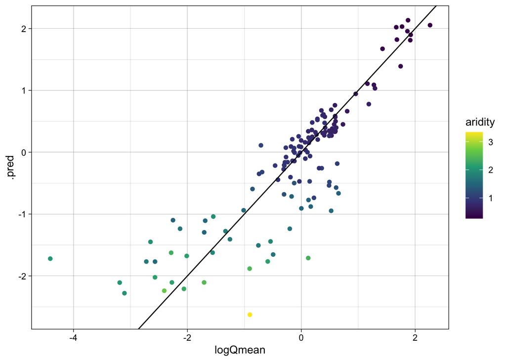

```r
ggplot(lm_data, aes(x = logQmean, y = .pred, colour = aridity)) +
  scale_color_viridis_c() +
  geom_point() +
  geom_abline() +
  theme_linedraw()
```

```r
library(baguette)
rf_model <- rand_forest() %>%
  set_engine("ranger", importance = "impurity") %>%
  set_mode("regression")

rf_wf <- workflow() %>%
  add_recipe(rec) %>%
  add_model(rf_model) %>%
  fit(data = camels_train)

rf_data <- augment(rf_wf, new_data = camels_test)
dim(rf_data)
```

```
[1] 135  60
```

```r
metrics(rf_data, truth = logQmean, estimate = .pred)
```

```
# A tibble: 3 × 3
  .metric .estimator .estimate
  <chr>   <chr>          <dbl>
1 rmse    standard       0.587
2 rsq     standard       0.741
3 mae     standard       0.363
```

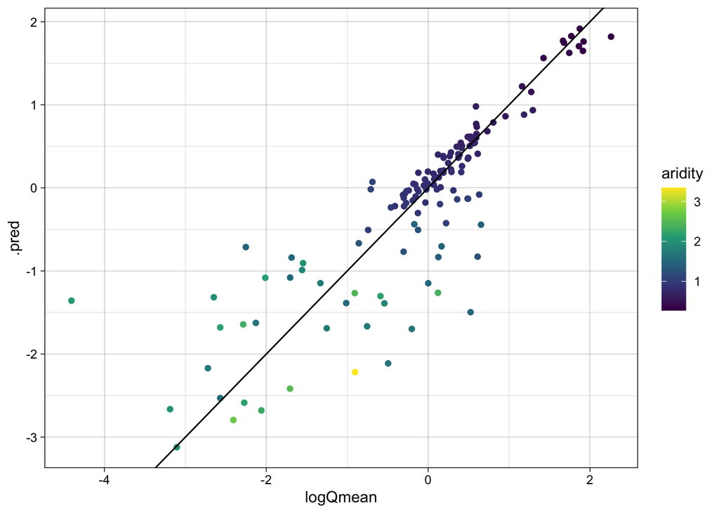

```r
ggplot(rf_data, aes(x = logQmean, y = .pred, colour = aridity)) +
  scale_color_viridis_c() +
  geom_point() +
  geom_abline() +
  theme_linedraw()
```

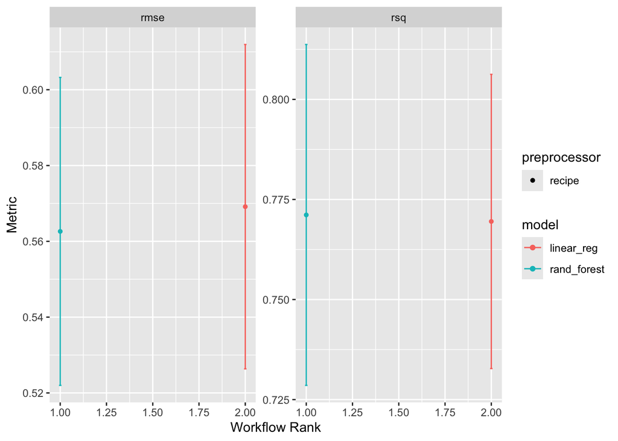

```r
wf <- workflow_set(list(rec), list(lm_model, rf_model)) %>%
  workflow_map('fit_resamples', resamples = camels_cv)

autoplot(wf)
```

```r
rank_results(wf, rank_metric = "rsq", select_best = TRUE)
```

```
# A tibble: 4 × 9
  wflow_id          .config .metric  mean std_err     n preprocessor model  rank
  <chr>             <chr>   <chr>   <dbl>   <dbl> <int> <chr>        <chr> <int>
1 recipe_rand_fore… Prepro… rmse    0.563  0.0247    10 recipe       rand…     1
2 recipe_rand_fore… Prepro… rsq     0.771  0.0259    10 recipe       rand…     1
3 recipe_linear_reg Prepro… rmse    0.569  0.0260    10 recipe       line…     2
4 recipe_linear_reg Prepro… rsq     0.770  0.0223    10 recipe       line…     2
```

# Question 3

```r
# Boost Tree
bt_model <- boost_tree() %>%
  set_engine("xgboost") %>%
  set_mode("regression")

bt_wf <- workflow() %>%
  add_recipe(rec) %>%
  add_model(bt_model) %>%
  fit(data = camels_train)

bt_data <- augment(bt_wf, new_data = camels_test)
dim(bt_data)
```

```
[1] 135  60
```

```r
metrics(bt_data, truth = logQmean, estimate = .pred)
```

```
# A tibble: 3 × 3
  .metric .estimator .estimate
  <chr>   <chr>          <dbl>
1 rmse    standard       0.631
2 rsq     standard       0.702
3 mae     standard       0.397
```

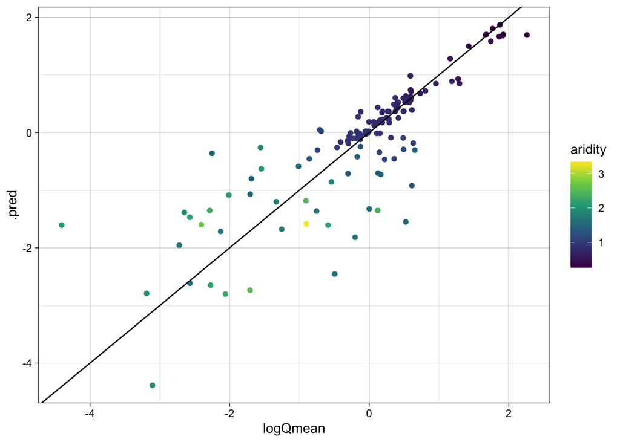

```r
ggplot(bt_data, aes(x = logQmean, y = .pred, colour = aridity)) +
  scale_color_viridis_c() +
  geom_point() +
  geom_abline() +
  theme_linedraw()
```

```r
# Neural Network
nnet_model <- bag_mlp() %>%
  set_engine("nnet") %>%
  set_mode("regression")

nnet_wf <- workflow() %>%
  add_recipe(rec) %>%
  add_model(nnet_model) %>%
  fit(data = camels_train)

nnet_data <- augment(nnet_wf, new_data = camels_test)
dim(nnet_data)
```

```
[1] 135  61
```

```r
metrics(nnet_data, truth = logQmean, estimate = .pred)
```

```
# A tibble: 3 × 3
  .metric .estimator .estimate
  <chr>   <chr>          <dbl>
1 rmse    standard       0.545
2 rsq     standard       0.772
3 mae     standard       0.337
```

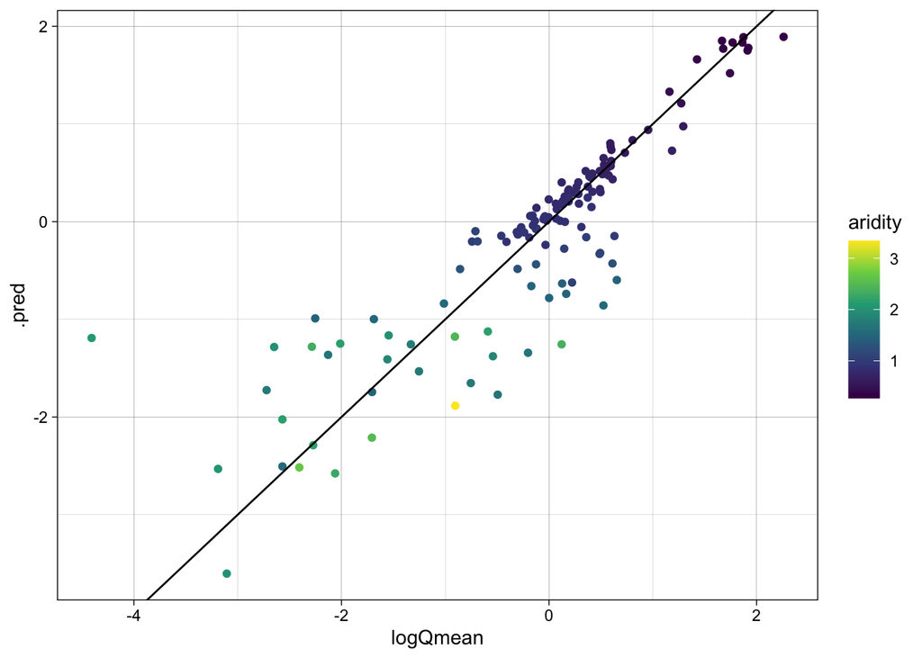

```r
ggplot(nnet_data, aes(x = logQmean, y = .pred, colour = aridity)) +
  scale_color_viridis_c() +
  geom_point() +
  geom_abline() +
  theme_linedraw()
```

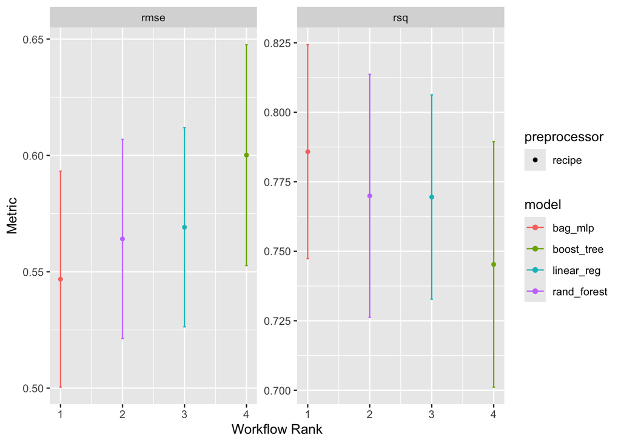

```r
# Add to existing workflow
wf <- workflow_set(list(rec), list(lm_model, rf_model, nnet_model, bt_model)) %>%
  workflow_map('fit_resamples', resamples = camels_cv)

autoplot(wf)
```

```r
rank_results(wf, rank_metric = "rsq", select_best = TRUE)
```

```
# A tibble: 8 × 9
  wflow_id          .config .metric  mean std_err     n preprocessor model  rank
  <chr>             <chr>   <chr>   <dbl>   <dbl> <int> <chr>        <chr> <int>
1 recipe_bag_mlp    Prepro… rmse    0.547  0.0282    10 recipe       bag_…     1
2 recipe_bag_mlp    Prepro… rsq     0.786  0.0234    10 recipe       bag_…     1
3 recipe_rand_fore… Prepro… rmse    0.564  0.0260    10 recipe       rand…     2
4 recipe_rand_fore… Prepro… rsq     0.770  0.0266    10 recipe       rand…     2
5 recipe_linear_reg Prepro… rmse    0.569  0.0260    10 recipe       line…     3
6 recipe_linear_reg Prepro… rsq     0.770  0.0223    10 recipe       line…     3
7 recipe_boost_tree Prepro… rmse    0.600  0.0289    10 recipe       boos…     4
8 recipe_boost_tree Prepro… rsq     0.745  0.0268    10 recipe       boos…     4
```

Compared to the other two models, the Neural Network model outperforms the other models and the Xgboost Regression model underperforms the other models. The linear model is still ranked above the Xgboost model and this could be because the tree-based method of the Xgboost model was not able to capture complexities in the relatively small dataset. However, the linear model was outperformed by the random forest model and neural network, suggesting a simple linear relationship is not sufficient to explain the interactions between terms. The flexible nature of the Neural Network model and its ability to capture complexities of the dataset and learn from complex interactions makes it the best model, as demonstrated in the above table and graph. For these reasons I would continue with the Neural Network model.

# Build Your Own

```r
#Data Splitting
set.seed(124)

camels <- camels %>%
  mutate(logQmean = log(q_mean)) %>%
  select(logQmean, p_mean, aridity, soil_depth_pelletier, max_water_content, organic_frac, frac_snow, pet_mean, soil_depth_statsgo, elev_mean) %>%
  drop_na()

c_split <- initial_split(camels, prop = 0.8)
c_train <- training(c_split)
c_test  <- testing(c_split)

c_cv <- vfold_cv(c_train, v = 10)
```

```r
# Recipe
rec2 <-  recipe(logQmean ~ . , data = c_train) %>%
  step_scale(all_predictors()) %>%
  step_center(all_predictors())
```

I chose to use the above formula because it compares the predictors to the log transformed Q mean. Doing a log transformation on the Q mean proved to establish a more predictable relationship between the predictors p_mean and aridity, so I maintained this log transformation. Since there are many predictors, I chose to use step_scale and step_center to normalize the data on a universal scale and allow for more accurate model creation.

```r
c_baked <- prep(rec2, c_train) |>
  bake(new_data = NULL)

lm_base2 <- lm(logQmean ~ . , data = c_baked)
summary(lm_base2)
```

```
Call:
lm(formula = logQmean ~ ., data = c_baked)

Residuals:
    Min      1Q  Median      3Q     Max
-2.7726 -0.1543  0.0502  0.2400  3.9490

Coefficients:
                      Estimate Std. Error t value Pr(>|t|)
(Intercept)          -0.081749   0.022536  -3.627 0.000314 ***
p_mean                0.532187   0.039029  13.636  < 2e-16 ***
aridity              -0.643846   0.049819 -12.924  < 2e-16 ***
soil_depth_pelletier -0.077194   0.029114  -2.651 0.008256 **
max_water_content     0.058350   0.043250   1.349 0.177877
organic_frac          0.005265   0.025468   0.207 0.836304
frac_snow             0.287464   0.051639   5.567 4.14e-08 ***
pet_mean              0.137612   0.028827   4.774 2.35e-06 ***
soil_depth_statsgo   -0.156120   0.039232  -3.979 7.88e-05 ***
elev_mean             0.034353   0.057964   0.593 0.553668
---
Signif. codes:  0 '***' 0.001 '**' 0.01 '*' 0.05 '.' 0.1 ' ' 1

Residual standard error: 0.5218 on 526 degrees of freedom
Multiple R-squared:  0.8012,    Adjusted R-squared:  0.7978
F-statistic: 235.5 on 9 and 526 DF,  p-value: < 2.2e-16
```

```r
# Linear Model
lm_model2 <- linear_reg() %>%
  set_engine("lm") %>%
  set_mode("regression")

lm_wf2 <- workflow() %>%
  add_recipe(rec2) %>%
  add_model(lm_model2) %>%
  fit(data = c_train)
summary(extract_fit_engine(lm_wf2))$coefficients
```

```
                         Estimate Std. Error     t value     Pr(>|t|)
(Intercept)          -0.081748780 0.02253641  -3.6274094 3.141820e-04
p_mean                0.532187271 0.03902852  13.6358550 1.809987e-36
aridity              -0.643845847 0.04981868 -12.9237847 2.239196e-33
soil_depth_pelletier -0.077194364 0.02911388  -2.6514630 8.256109e-03
max_water_content     0.058350264 0.04325039   1.3491270 1.778766e-01
organic_frac          0.005264932 0.02546817   0.2067260 8.363039e-01
frac_snow             0.287464074 0.05163924   5.5667757 4.141554e-08
pet_mean              0.137611570 0.02882695   4.7737118 2.347449e-06
soil_depth_statsgo   -0.156119578 0.03923198  -3.9793961 7.878971e-05
elev_mean             0.034352637 0.05796409   0.5926537 5.536676e-01
```

```r
lm_data2 <- augment(lm_wf2, new_data = c_test)
metrics(lm_data2, truth = logQmean, estimate = .pred)
```

```
# A tibble: 3 × 3
  .metric .estimator .estimate
  <chr>   <chr>          <dbl>
1 rmse    standard       0.447
2 rsq     standard       0.874
3 mae     standard       0.302
```

```r
# Random Forest Model
rf_model2 <- rand_forest() %>%
  set_engine("ranger") %>%
  set_mode("regression")

rf_wf2 <- workflow() %>%
  add_recipe(rec2) %>%
  add_model(rf_model2) %>%
  fit(data = c_train)

rf_data2 <- augment(rf_wf2, new_data = c_test)
metrics(rf_data2, truth = logQmean, estimate = .pred)
```

```
# A tibble: 3 × 3
  .metric .estimator .estimate
  <chr>   <chr>          <dbl>
1 rmse    standard       0.290
2 rsq     standard       0.946
3 mae     standard       0.191
```

```r
# Boost Tree
bt_model2 <- boost_tree() %>%
  set_engine("xgboost") %>%
  set_mode("regression")

bt_wf2 <- workflow() %>%
  add_recipe(rec2) %>%
  add_model(bt_model2) %>%
  fit(data = c_train)

bt_data2 <- augment(bt_wf2, new_data = c_test)

metrics(bt_data2, truth = logQmean, estimate = .pred)
```

```
# A tibble: 3 × 3
  .metric .estimator .estimate
  <chr>   <chr>          <dbl>
1 rmse    standard       0.384
2 rsq     standard       0.903
3 mae     standard       0.241
```

```r
# Neural Network

nnet_model2 <- bag_mlp() %>%
  set_engine("nnet") %>%
  set_mode("regression")

nnet_wf2 <- workflow() %>%
  add_recipe(rec2) %>%
  add_model(nnet_model2) %>%
  fit(data = c_train)

nnet_data2 <- augment(nnet_wf2, new_data = c_test)

metrics(nnet_data2, truth = logQmean, estimate = .pred)
```

```
# A tibble: 3 × 3
  .metric .estimator .estimate
  <chr>   <chr>          <dbl>
1 rmse    standard       0.303
2 rsq     standard       0.943
3 mae     standard       0.203
```

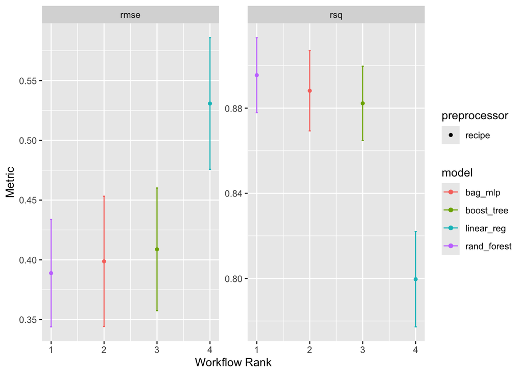

```r
# Workflow Set
wf2 <- workflow_set(list(rec2), list(lm_model2, rf_model2, nnet_model2, bt_model2)) %>%
  workflow_map('fit_resamples', resamples = c_cv)
# Evaluation
autoplot(wf2)
```

```r
rank_results(wf2, rank_metric = "rsq", select_best = TRUE)
```

```
# A tibble: 8 × 9
  wflow_id          .config .metric  mean std_err     n preprocessor model  rank
  <chr>             <chr>   <chr>   <dbl>   <dbl> <int> <chr>        <chr> <int>
1 recipe_rand_fore… Prepro… rmse    0.389  0.0273    10 recipe       rand…     1
2 recipe_rand_fore… Prepro… rsq     0.896  0.0107    10 recipe       rand…     1
3 recipe_bag_mlp    Prepro… rmse    0.399  0.0331    10 recipe       bag_…     2
4 recipe_bag_mlp    Prepro… rsq     0.888  0.0115    10 recipe       bag_…     2
5 recipe_boost_tree Prepro… rmse    0.409  0.0312    10 recipe       boos…     3
6 recipe_boost_tree Prepro… rsq     0.882  0.0106    10 recipe       boos…     3
7 recipe_linear_reg Prepro… rmse    0.531  0.0335    10 recipe       line…     4
8 recipe_linear_reg Prepro… rsq     0.800  0.0136    10 recipe       line…     4
```

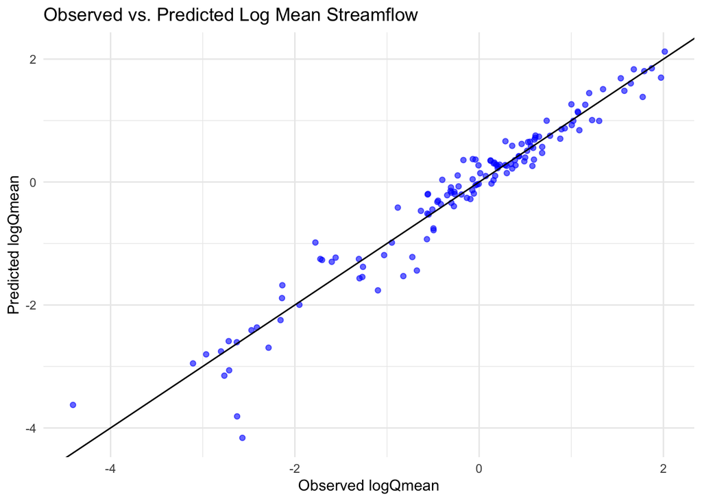

```r
# Extract and Evaluate
# workflow created in initial model creation above
ggplot(nnet_data2, aes(x = logQmean, y = .pred)) +
  scale_color_viridis_c() +
  geom_point(color = "blue", alpha = 0.6) +
  geom_abline() +
  theme_linedraw() +
  labs(
    title = "Observed vs. Predicted Log Mean Streamflow",
    x = "Observed logQmean",
    y = "Predicted logQmean"
  ) +
  theme_minimal()
```

The model seems to be a good fit for predicting logQmean across a number of predictor variables. The line of best fit represents the overall trend and slope of the data, although there is some variation between actual and predicted values. I think this model could be fine tuned by including even more predictor variables to increase its predictive capacity. However, no model will be 100% accurate in predicting streamflow on a given day due to daily variations and the presence of outliers, so I think this model is an excellent start for making predictions.